# Intelligent Data Analysis Assingment 2.1

## Francisco de Borja González Glez. (EIT)

## Francisco Santos Garcia (EIT)

## Fernando Díaz González(EIT)

## Ricardo García García (EIT)

## Sergio Cámara Braña (MUI)

The goal of this assingment is to obtain a model to predict the price (in Singapore dollars) of the diamonds using several variables and to improve it by solving the possible typical issues.

## Initial libraries

```r
library(GGally)
library(ggplot2)
library(gridExtra)
library(lmtest)
library(normtest)
library(tseries)
```

We load the data and create a new column with the log of price.

```r
diamantes <- read.table('diamonds.txt')
names(diamantes) <- c('Carats', 'Colour_purity', 'Clarity', 'Institution', 'Price')
diamantes$log_ <- log(diamantes$Price)
str(diamantes)
```

```
## 'data.frame':    308 obs. of  6 variables:
##  $ Carats       : num  0.3 0.3 0.3 0.3 0.31 0.31 0.31 0.31 0.31 0.31 ...
##  $ Colour_purity: Factor w/ 6 levels "D","E","F","G",..: 1 2 4 4 1 2 3 4 5 6 ...
##  $ Clarity      : Factor w/ 5 levels "IF","VS1","VS2",..: 3 2 4 2 2 2 2 5 3 2 ...
##  $ Institution  : Factor w/ 3 levels "GIA","HRD","IGI": 1 1 1 1 1 1 1 1 1 1 ...
##  $ Price        : int  1302 1510 1510 1260 1641 1555 1427 1427 1126 1126 ...
##  $ log_         : num  7.17 7.32 7.32 7.14 7.4 ...
```

## 1.- Predicting price or log(price)?

In order to see which variable is better to be predicted we will do some basic scatter plots of both variables.

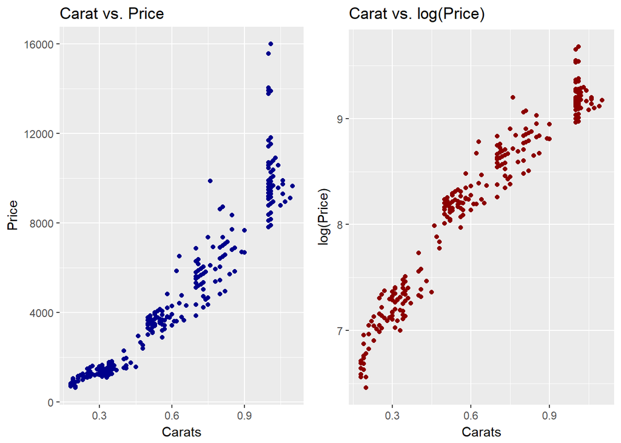

```r
p1 <- ggplot(diamantes, aes(x=Carats, y=Price))+geom_point(color = 'darkblue')+ ggtitle('Carat vs. Price')
p2 <- ggplot(diamantes, aes(x=Carats, y=log(Price)))+geom_point(color ='darkred') + ggtitle('Carat vs. log(Price)')
grid.arrange(p1, p2, ncol=2)
```

The result we can infer from this plot is that it is not pretty clear wich variable is the better to be predicted. We can see that maybe log(price) is a little bit more linear to carats than price but we can assure it by using:

```r
simple1=lm(diamantes$Price ~ Carats, data = diamantes)
summary(simple1)[8]
```

```
## $r.squared
## [1] 0.8925084
```

```r
simple2=lm(diamantes$log_ ~ Carats, data = diamantes)
summary(simple2)[8]
```

```
## $r.squared
## [1] 0.9355391
```

So, from now on we will be using log(Price) since the R-squared coeff is closer to 1.

## 2.- Linear Model with Categorical Variables.

To include the categorical variables we have in our dataset we have to make reference states and then perform our model.

```r
diamantes$Colour_purity = relevel(diamantes$Colour_purity, ref="I")
diamantes$Clarity = relevel(diamantes$Clarity, ref="VS2")
diamantes$Institution  = relevel(diamantes$Institution, ref="HRD")

model1 = lm(log_~Carats + Clarity + Colour_purity + Institution, data = diamantes)
summary(model1)
```

```
##
## Call:
## lm(formula = log_ ~ Carats + Clarity + Colour_purity + Institution,
##     data = diamantes)
##
## Residuals:
##      Min       1Q   Median       3Q      Max
## -0.31236 -0.11520  0.01613  0.10833  0.36339
##
## Coefficients:
##                 Estimate Std. Error t value Pr(>|t|)
## (Intercept)     6.077239   0.048091 126.369  < 2e-16 ***
## Carats          2.855013   0.036968  77.230  < 2e-16 ***
## ClarityIF       0.298541   0.033303   8.964  < 2e-16 ***
## ClarityVS1      0.096609   0.024919   3.877  0.00013 ***
## ClarityVVS1     0.297835   0.028102  10.598  < 2e-16 ***
## ClarityVVS2     0.201923   0.025344   7.967 3.56e-14 ***
## Colour_purityD  0.416557   0.041382  10.066  < 2e-16 ***
## Colour_purityE  0.387047   0.030824  12.557  < 2e-16 ***
## Colour_purityF  0.310198   0.027479  11.288  < 2e-16 ***
## Colour_purityG  0.210207   0.028359   7.412 1.32e-12 ***
## Colour_purityH  0.128681   0.028523   4.511 9.31e-06 ***
## InstitutionGIA  0.008856   0.020864   0.424  0.67155
## InstitutionIGI -0.173855   0.028673  -6.063 4.07e-09 ***
## ---
## Signif. codes:  0 '***' 0.001 '**' 0.01 '*' 0.05 '.' 0.1 ' ' 1
##
## Residual standard error: 0.1382 on 295 degrees of freedom
## Multiple R-squared:  0.9723, Adjusted R-squared:  0.9712
## F-statistic: 863.6 on 12 and 295 DF,  p-value: < 2.2e-16
```

Another thing we can observe is that all the p-values are low enough (pv < 0.05) to reject the null hypothesis that says those $\beta$ are equal to 0, except for the GIA institution. The p-value of the whole model is low enough to accept this lineality on the model, in fact, the Multiple R-squared which is the common metric of linear models is pretty good since it is very close to 1. This coefficient is calculated by using covariances between the target variable and the model and with their standard deviations. The utility of using the lowest level of each variable as the base category is in order to get the $\beta$ > 0, otherwise if you for example use the highest value of the categorical variable you will get the same absolut value of the Bs from the categories but with a different sign (-, in this case).

## OUTLIERS STUDY

Firstly we will perform some basics analisys on the residuals with some easy plots:

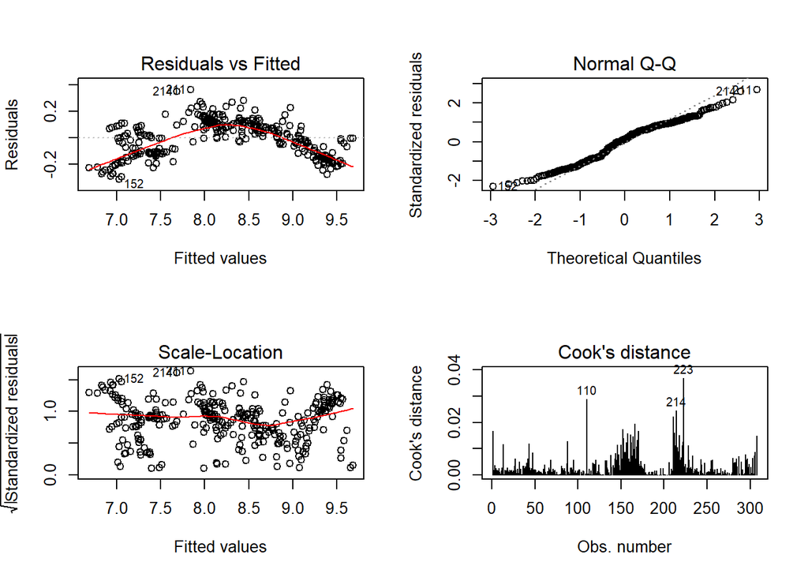

```r
par(mfrow=c(2,2))
plot(model1, which=c(1:4), ask=F)
```

```r
out_list <- c(diamantes[110,'Carats'],diamantes[214,'Carats'],diamantes[223,'Carats'])
k <- diamantes[diamantes$Carats == out_list[1],]
k[order(k$Price),]
```

```
##     Carats Colour_purity Clarity Institution Price     log_
## 224   0.76             F    VVS2         IGI  6095 8.715224
## 110   0.76             D      IF         GIA  9885 9.198774
```

```r
q <- diamantes[diamantes$Carats == out_list[2],]
q[order(q$Price),]
```

```
##     Carats Colour_purity Clarity Institution Price     log_
## 214   0.52             I      IF         IGI  3095 8.037543
## 234   0.52             H    VVS1         HRD  3130 8.048788
## 233   0.52             E     VS2         HRD  3346 8.115521
## 46    0.52             F     VS1         GIA  3418 8.136811
## 43    0.52             D     VS2         GIA  3490 8.157657
## 44    0.52             E     VS1         GIA  3635 8.198364
## 45    0.52             F    VVS2         GIA  3635 8.198364
```

```r
l <- diamantes[diamantes$Carats == out_list[3],]
l[order(l$Price),]
```

```
##     Carats Colour_purity Clarity Institution Price     log_
## 71    0.71             F     VS2         GIA  5193 8.555067
## 72    0.71             H    VVS2         GIA  5193 8.555067
## 97    0.71             H    VVS2         GIA  5193 8.555067
## 257   0.71             H    VVS2         HRD  5193 8.555067
## 70    0.71             F     VS1         GIA  5586 8.628019
## 69    0.71             F    VVS2         GIA  5881 8.679482
## 96    0.71             E     VS1         GIA  5881 8.679482
## 223   0.71             D     VS1         IGI  6160 8.725832
## 95    0.71             D     VS1         GIA  6372 8.759669
## 256   0.71             G      IF         HRD  6372 8.759669
```

Related to the residuals plots, since it is a model that has more than 1 explanatory variable is not that easy to understand the residuals plots as it is in a one variable linear model that can be analysed with just a simple plot.

Variance of the residuals does not seem to be constant but we can not be sure just by looking at the plots. Lets perform the Breusch-Pagan test that has an initial hypothesis constant variance of the residuals:

```r
bptest(model1)
```

```
##
##  studentized Breusch-Pagan test
##
## data:  model1
## BP = 47.223, df = 12, p-value = 4.265e-06
```

The low p-value rejects $H_0$ so our variance of the residuals is not constant.

Now, we will check the autocorrelation of the residuals with the Durbin-Watson test which has the null hypothesis that the autocorrelation of the residuals is 0 which is not given its low p-value:

```r
dwtest(model1)
```

```
##
##  Durbin-Watson test
##
## data:  model1
## DW = 0.31422, p-value < 2.2e-16
## alternative hypothesis: true autocorrelation is greater than 0
```

Residuals seem to follow a rather normal distrubution:

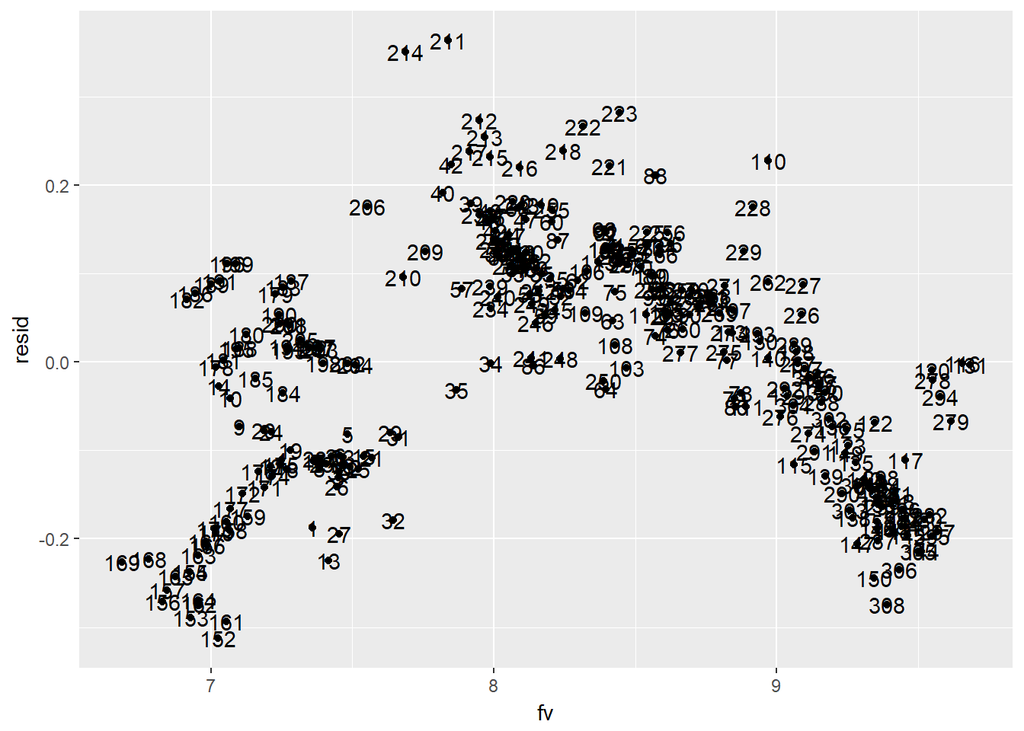

```r
resid=residuals(model1)
fv=fitted(model1)
ggplot(diamantes, aes(x=fv, y=resid))+geom_point()+geom_text(label=rownames(diamantes))
```

Let us check this assumption with the jarque-bera test.

```r
jarque.bera.test(resid)
```

```
##
##  Jarque Bera Test
##
## data:  resid
## X-squared = 8.0626, df = 2, p-value = 0.01775
```

```r
##diamantes2 <- diamantes[-c(110,214,223)]
```

But jarque-bera test denies this assumption. Now it is time to try some remedial actions.

## 3(a).- Remedial Actions

Firstly, we have to create a new categorical variable based on the size of the diamonds and small will be the reference category.

```r
diamantes$carat_2 <- 0
diamantes[diamantes$Carats< 0.5,"carat_2"] <- "small"
diamantes[diamantes$Carats>= 0.5 & diamantes$Carats< 1.0 ,"carat_2"] <- "medium"
diamantes[diamantes$Carats >= 1.0,"carat_2"] <- "large"
diamantes$carat_2 = as.factor(diamantes$carat_2)
diamantes$carat_2 = relevel(diamantes$carat_2, ref="small")
```

And now we compute the model with an interaction term:

```r
model2 = lm(log_~Carats + Clarity + Colour_purity + Institution + carat_2 + carat_2*Carats, data = diamantes)
summary(model2)
```

```
##
## Call:
## lm(formula = log_ ~ Carats + Clarity + Colour_purity + Institution +
##     carat_2 + carat_2 * Carats, data = diamantes)
##
## Residuals:
##       Min        1Q    Median        3Q       Max
## -0.162232 -0.036601  0.003364  0.039892  0.140706
##
## Coefficients:
##                       Estimate Std. Error t value Pr(>|t|)
## (Intercept)           5.530676   0.032878 168.218  < 2e-16 ***
## Carats                4.257150   0.085503  49.790  < 2e-16 ***
## ClarityIF             0.311385   0.013543  22.992  < 2e-16 ***
## ClarityVS1            0.068240   0.010060   6.783 6.56e-11 ***
## ClarityVVS1           0.213344   0.011536  18.493  < 2e-16 ***
## ClarityVVS2           0.134180   0.010351  12.963  < 2e-16 ***
## Colour_purityD        0.433562   0.016897  25.659  < 2e-16 ***
## Colour_purityE        0.348679   0.012550  27.784  < 2e-16 ***
## Colour_purityF        0.272843   0.011142  24.488  < 2e-16 ***
## Colour_purityG        0.187887   0.011522  16.307  < 2e-16 ***
## Colour_purityH        0.107866   0.011481   9.395  < 2e-16 ***
## InstitutionGIA        0.007703   0.008473   0.909    0.364
## InstitutionIGI       -0.016726   0.012177  -1.374    0.171
## carat_2large          2.376272   0.319800   7.430 1.21e-12 ***
## carat_2medium         0.946026   0.039091  24.201  < 2e-16 ***
## Carats:carat_2large  -3.259971   0.323445 -10.079  < 2e-16 ***
## Carats:carat_2medium -1.765492   0.093498 -18.883  < 2e-16 ***
## ---
## Signif. codes:  0 '***' 0.001 '**' 0.01 '*' 0.05 '.' 0.1 ' ' 1
##
## Residual standard error: 0.0554 on 291 degrees of freedom
## Multiple R-squared:  0.9956, Adjusted R-squared:  0.9954
## F-statistic:  4127 on 16 and 291 DF,  p-value: < 2.2e-16
```

We can observe that we have achieved a higher value of the R-Squared coefficient so a priori the model is better now. My intuition made me think that this was not going to improve the model because we have just created two variables out of the ones we already had so there was not going to be new information in the model. But I was wrong. But we still have to make an analysis of the residuals.

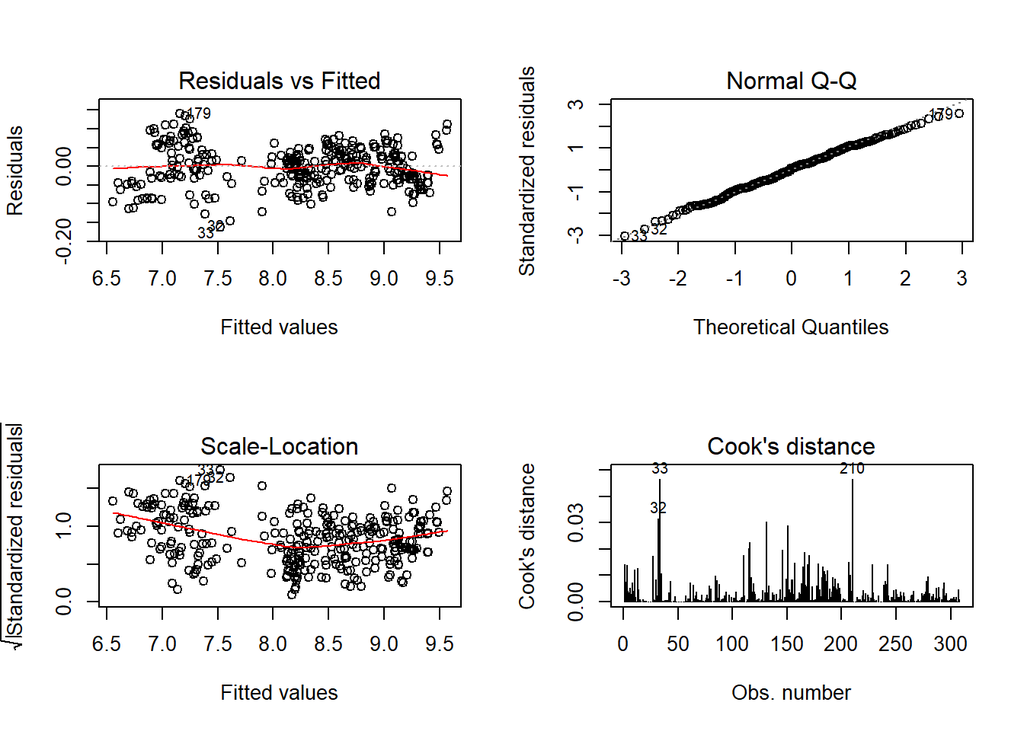

```r
par(mfrow=c(2,2))
plot(model2, which=c(1:4), ask=F)
```

And we will perform the same tests as we did in the model before to try to understand what has changed.

Variance, autocorrelation and normality of the resiudals:

```r
bptest(model2)
```

```
##
##  studentized Breusch-Pagan test
##
## data:  model2
## BP = 60.618, df = 16, p-value = 4.117e-07
```

```r
dwtest(model2)
```

```
##
##  Durbin-Watson test
##
## data:  model2
## DW = 1.0398, p-value < 2.2e-16
## alternative hypothesis: true autocorrelation is greater than 0
```

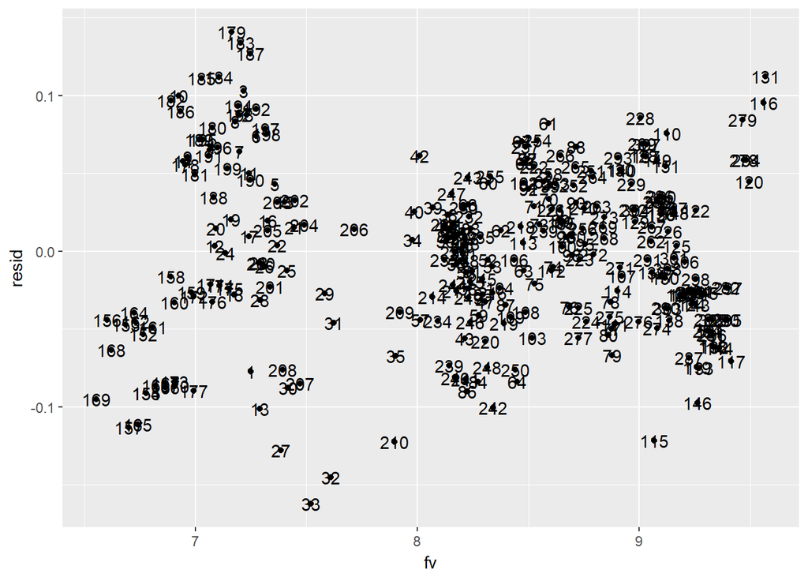

```r
resid=residuals(model2)
fv=fitted(model2)
ggplot(diamantes, aes(x=fv, y=resid))+geom_point()+geom_text(label=rownames(diamantes))
```

```r
jarque.bera.test(resid)
```

```
##
##  Jarque Bera Test
##
## data:  resid
## X-squared = 1.3424, df = 2, p-value = 0.5111
```

The results of the test show autocorrelation so they are not independent with a non constant variance and showing normality in the distribution. So the model has improved related to the study and the residuals and in terms of variance explanation as the root mean squared coefficient suggests.

The interaction term may seem a little confusing since one would expect that the larger a diamond is, the higher the priceis, and both interaction terms are negative.

In order to evalute which variable is more important to decide the price of the diamonds between colour or clarity since they are both categorical variables we can calculate the average value of the $\beta$ values of the categories. Purity has clearly a bigger value than clarity, so we can conclude than it is more important for the model.

Related to the instituion analysis, we have same things as before but there is the IGI with a negative value of the $\beta$ so the difference of prices with IGI will be higher than the difference between the other ones. Once again one should get the factor of difference between them, as a example: $\beta_{GIA} - \beta_{IGI} \approx 0.18$ so the price of GIA is approx 1.18 times bigger than IGI. Since $\beta_{GIA}$ has a pretty low value the price will be very similiar to HRD diamonds.

## 3(b).- Square of Carats as an explanatory variable.

```r
model3 = update(model1, ~.+I(scale(Carats, scale = F)^2))
summary(model3)
```

```
##
## Call:
## lm(formula = log_ ~ Carats + Clarity + Colour_purity + Institution +
##     I(scale(Carats, scale = F)^2), data = diamantes)
##
## Residuals:
##      Min       1Q   Median       3Q      Max
## -0.15411 -0.04120 -0.00911  0.04543  0.14158
##
## Coefficients:
##                                Estimate Std. Error t value Pr(>|t|)
## (Intercept)                    6.143399   0.020682 297.043  < 2e-16 ***
## Carats                         3.017111   0.016455 183.350  < 2e-16 ***
## ClarityIF                      0.320183   0.014279  22.424  < 2e-16 ***
## ClarityVS1                     0.075713   0.010690   7.083 1.05e-11 ***
## ClarityVVS1                    0.226174   0.012199  18.540  < 2e-16 ***
## ClarityVVS2                    0.143481   0.010976  13.072  < 2e-16 ***
## Colour_purityD                 0.442606   0.017742  24.947  < 2e-16 ***
## Colour_purityE                 0.363359   0.013220  27.485  < 2e-16 ***
## Colour_purityF                 0.286615   0.011789  24.311  < 2e-16 ***
## Colour_purityG                 0.197573   0.012153  16.257  < 2e-16 ***
## Colour_purityH                 0.103508   0.012238   8.458 1.30e-15 ***
## InstitutionGIA                 0.006223   0.008938   0.696    0.487
## InstitutionIGI                -0.019190   0.013003  -1.476    0.141
## I(scale(Carats, scale = F)^2) -2.102922   0.058022 -36.243  < 2e-16 ***
## ---
## Signif. codes:  0 '***' 0.001 '**' 0.01 '*' 0.05 '.' 0.1 ' ' 1
##
## Residual standard error: 0.0592 on 294 degrees of freedom
## Multiple R-squared:  0.9949, Adjusted R-squared:  0.9947
## F-statistic:  4445 on 13 and 294 DF,  p-value: < 2.2e-16
```

```r
# model4 = lm(Price~Carats + Clarity + Colour_purity + Institution
#             +I(scale(Carats, scale = F)^2)
#             , data = diamantes)
# summary(model4)
```

We can infer that the value of the R squared coefficient has improved related to the original model but it is slighty worse than the coefficient of the model before. But it is very close to 1 as well. The p-value is pretty low so we can reject the null hypothesis of a 0 value of the $\beta$ that multiplies the quadratic term. If we perform once again the residuals tests:

```r
dwtest(model3)
```

```
##
##  Durbin-Watson test
##
## data:  model3
## DW = 0.98039, p-value < 2.2e-16
## alternative hypothesis: true autocorrelation is greater than 0
```

```r
bptest(model3)
```

```
##
##  studentized Breusch-Pagan test
##
## data:  model3
## BP = 16.094, df = 13, p-value = 0.2441
```

## 4.- Which model is better?

Both of the models have a very nice R-squared coefficient very close to 1. Related to residuals the model of the square of the caratage achieves homocedastic residuals but none of the models have indenpendent residuals. In my opinion the second remedial action is better because it is more easy to be interpreted and understood since the interaction term is not that trivial for me, eventhough the clustered model seems to be more accurated with just a simple clasification of the variable. The simple, the better.